# PowerpuffGirls - Iowa Liquor Sales Analysis

### Group Name: PowerpuffGirls

### Project: Iowa Liquor Sales Analysis

### Group Members: Khang Le (Kayla) Tan, Poorvika Bhat, Thu Nguyen

## Objective and Data Description

United State is one of the countries where people consume alcohol on daily basis. As Business Analysts, we want to perform a detailed analysis on this topic to understand the trend of alcohol consumption in our home State - Iowa.

Our group has collected the data from Iowa Government Website (https://data.iowa.gov/Sales-Distribution/Iowa-Liquor-Sales/m3tr-qhgy/data). We did not have any challenges in downloading the dataset as it is publicly available. The dataset contains date, store number, store name, locations, county, liquor category, vendor information, item description, pack, bottle volume (ml), bottle sold, volume sold (liters and gallons), cost, sales, etc.

## Analysis we would like to do

• Visualize the store location across Iowa using Geopandas.

• What is the trend of liquor sales across various year?

• What is the trend of liquor sales across months for different categories and years?

• What is the most preferred liquor type for different years?

• Identify the top 10 and bottom 10 stores or vendors based on sales.

• What is the most significant variable that influences the liquor sales of a store in Iowa?

## Importing Python Packages and installing required packages

```python
!pip install --upgrade pip
!pip install geopandas
!pip install --user scikit-learn==1.0.1
```

```python
import pandas as pd
import numpy as np
import matplotlib.pyplot as plt
import seaborn as sns
import datetime as dt
import calendar
import os
import geopandas as gpd
from shapely.geometry import Point
from ipywidgets import widgets, interactive, Layout
from sklearn import linear_model
from sklearn.model_selection import train_test_split
import statsmodels.api as sms


%matplotlib inline
os.getcwd()
```

```
'/home/ktan4/groupdata/group06'
```

## Importing data from csv files into a single consolidated dataframe

```python
years = [2019, 2020, 2021]
liquorSales = pd.DataFrame()

for year in years:

    location = str(year) + "_Iowa_Liquor_Sales.csv"
    globals()['liquorSales_%s' % year] = pd.read_csv(location,sep = ',')

    liquorSales = liquorSales.append(globals()['liquorSales_%s' % year])
```

## Data Exploration

```python
# Display numeric columns
liquorSales_numeric = liquorSales.select_dtypes(include=[np.number])
numeric_cols = liquorSales_numeric.columns.values

print(numeric_cols)
```

```
['Store Number' 'Zip Code' 'County Number' 'Category' 'Vendor Number'
 'Item Number' 'Pack' 'Bottle Volume (ml)' 'State Bottle Cost'
 'State Bottle Retail' 'Bottles Sold' 'Sale (Dollars)'
 'Volume Sold (Liters)' 'Volume Sold (Gallons)']
```

```python
# Display non-numeric columns
liquorSales_non_numeric = liquorSales.select_dtypes(exclude=[np.number])
non_numeric_cols = liquorSales_non_numeric.columns.values

print(non_numeric_cols)
```

```
['Invoice/Item Number' 'Date' 'Store Name' 'Address' 'City'
 'Store Location' 'County' 'Category Name' 'Vendor Name'
 'Item Description']
```

```python
liquorSales.head()
```

|  | Invoice/Item Number | Date | Store Number | Store Name | Address | City | Zip Code | Store Location | County Number | County | ... | Item Number | Item Description | Pack | Bottle Volume (ml) | State Bottle Cost | State Bottle Retail | Bottles Sold | Sale (Dollars) | Volume Sold (Liters) | Volume Sold (Gallons) |
| --- | --- | --- | --- | --- | --- | --- | --- | --- | --- | --- | --- | --- | --- | --- | --- | --- | --- | --- | --- | --- | --- |
| 0 | INV-16681900011 | 01/02/2019 | 5286 | Sauce | 108, College | Iowa City | 52240.0 | NaN | 52.0 | JOHNSON | ... | 48099 | Hennessy VS | 24 | 200 | 6.24 | 9.36 | 24 | 224.64 | 4.8 | 1.26 |
| 1 | INV-16681900027 | 01/02/2019 | 5286 | Sauce | 108, College | Iowa City | 52240.0 | NaN | 52.0 | JOHNSON | ... | 89191 | Jose Cuervo Especial Reposado Mini | 12 | 500 | 11.50 | 17.25 | 12 | 207.00 | 6.0 | 1.58 |
| 2 | INV-16681900018 | 01/02/2019 | 5286 | Sauce | 108, College | Iowa City | 52240.0 | NaN | 52.0 | JOHNSON | ... | 8824 | Lauder's | 24 | 375 | 3.21 | 4.82 | 24 | 115.68 | 9.0 | 2.37 |
| 3 | INV-16685400036 | 01/02/2019 | 2524 | Hy-Vee Food Store / Dubuque | 3500 Dodge St | Dubuque | 52001.0 | NaN | 31.0 | DUBUQUE | ... | 35917 | Five O'Clock Vodka | 12 | 1000 | 4.17 | 6.26 | 12 | 75.12 | 12.0 | 3.17 |
| 4 | INV-16690300035 | 01/02/2019 | 4449 | Kum & Go #121 / Urbandale | 12041 Douglas Pkwy | Urbandale | 50322.0 | NaN | 77.0 | POLK | ... | 36304 | Hawkeye Vodka | 24 | 375 | 1.86 | 2.79 | 24 | 66.96 | 9.0 | 2.37 |

5 rows × 24 columns

```python
liquorSales.tail()
```

|  | Invoice/Item Number | Date | Store Number | Store Name | Address | City | Zip Code | Store Location | County Number | County | ... | Item Number | Item Description | Pack | Bottle Volume (ml) | State Bottle Cost | State Bottle Retail | Bottles Sold | Sale (Dollars) | Volume Sold (Liters) | Volume Sold (Gallons) |
| --- | --- | --- | --- | --- | --- | --- | --- | --- | --- | --- | --- | --- | --- | --- | --- | --- | --- | --- | --- | --- | --- |
| 2145001 | INV-41505500001 | 10/31/2021 | 5957 | Liquor, Tobacco & Grocery / Dubuque | 1998 Jackson St | Dubuque | 52001.0 | POINT (-90.668277 42.511477) | 31.0 | DUBUQUE | ... | 21540 | Stagg Jr. | 6 | 750 | 25.99 | 38.99 | 1 | 38.99 | 0.75 | 0.19 |
| 2145002 | INV-41504300007 | 10/31/2021 | 5098 | Best Food Mart 3 LLC | 1621 University Ave | Des Moines | 50311.0 | NaN | 77.0 | POLK | ... | 32231 | Seagrams Extra Dry Gin Mini | 12 | 50 | 3.30 | 4.95 | 12 | 59.40 | 0.60 | 0.15 |
| 2145003 | INV-41504300017 | 10/31/2021 | 5098 | Best Food Mart 3 LLC | 1621 University Ave | Des Moines | 50311.0 | NaN | 77.0 | POLK | ... | 64864 | Fireball Cinnamon Whiskey | 24 | 375 | 5.33 | 8.00 | 24 | 192.00 | 9.00 | 2.37 |
| 2145004 | INV-41504400005 | 10/31/2021 | 5906 | Polk City Liquor | 201 N 3rd St STE A and B | Polk City | 50226.0 | NaN | 77.0 | POLK | ... | 27677 | Cody Road Single Barrel | 6 | 750 | 25.00 | 37.50 | 2 | 75.00 | 1.50 | 0.39 |
| 2145005 | INV-41505000002 | 10/31/2021 | 6142 | Super Mart / Oelwein | 701 S Frederick Ave | Oelwein | 50662.0 | POINT (-91.913481 42.669128) | 33.0 | FAYETTE | ... | 26409 | Des Moines Whiskey | 6 | 750 | 30.33 | 45.50 | 4 | 182.00 | 3.00 | 0.79 |

5 rows × 24 columns

## Data Cleaning

```python
# Converting 'Date' column into datetime type
liquorSales['Date'] = pd.to_datetime(liquorSales['Date'])
liquorSales.info()
```

```
<class 'pandas.core.frame.DataFrame'>
Int64Index: 7139716 entries, 0 to 2145005
Data columns (total 24 columns):
 #   Column                 Dtype
---  ------                 -----
 0   Invoice/Item Number    object
 1   Date                   datetime64[ns]
 2   Store Number           int64
 3   Store Name             object
 4   Address                object
 5   City                   object
 6   Zip Code               float64
 7   Store Location         object
 8   County Number          float64
 9   County                 object
```

[output cut: 16 more lines]

```python
# % of missing
for col in liquorSales.columns:
    pct_missing = np.mean(liquorSales[col].isnull())
    print('{} - {}%'.format(col, pct_missing * 100))
```

```
Invoice/Item Number - 0.0%
Date - 0.0%
Store Number - 0.0%
Store Name - 0.0%
Address - 0.06952657500662492%
City - 0.06952657500662492%
Zip Code - 0.06952657500662492%
Store Location - 9.67161719037564%
County Number - 0.06952657500662492%
County - 0.06952657500662492%
Category - 0.050422173655086555%
Category Name - 0.050422173655086555%
Vendor Number - 7.003079674317578e-05%
Vendor Name - 7.003079674317578e-05%
Item Number - 0.0%
Item Description - 0.0%
Pack - 0.0%
Bottle Volume (ml) - 0.0%
State Bottle Cost - 0.0%
State Bottle Retail - 0.0%
Bottles Sold - 0.0%
Sale (Dollars) - 0.0%
Volume Sold (Liters) - 0.0%
Volume Sold (Gallons) - 0.0%
```

```python
# Remove all the rows that have Nan for Store location
liquorSales = liquorSales[liquorSales['Store Location'].notna()]
liquorSales['Store Location'].isna().any()
```

```
False
```

```python
# Remove all the rows that have Nan for Zip Code
liquorSales = liquorSales[liquorSales['Zip Code'].notna()]
liquorSales['Zip Code'].isna().any()
```

```
False
```

```python
# Imputing null values in Vendor Name with 'unknown'
liquorSales = liquorSales.fillna(value={'Vendor Name': 'unknown'})
liquorSales['Vendor Name'].isna().any()
```

```
False
```

```python
# Imputing null values in Vendor Number with 1000
liquorSales['Vendor Number'] = liquorSales['Vendor Number'].fillna(value = 1000)
```

```python
# Drop null values in the table
liquorSales.dropna()
```

|  | Invoice/Item Number | Date | Store Number | Store Name | Address | City | Zip Code | Store Location | County Number | County | ... | Item Number | Item Description | Pack | Bottle Volume (ml) | State Bottle Cost | State Bottle Retail | Bottles Sold | Sale (Dollars) | Volume Sold (Liters) | Volume Sold (Gallons) |
| --- | --- | --- | --- | --- | --- | --- | --- | --- | --- | --- | --- | --- | --- | --- | --- | --- | --- | --- | --- | --- | --- |
| 16 | INV-16677900018 | 2019-01-02 | 3870 | Target Store T-1939 / Altoona | 3414 8th St SW | Altoona | 50009.0 | POINT (-93.503783 41.644024) | 77.0 | POLK | ... | 27605 | Tin Cup | 12 | 750 | 13.75 | 20.63 | 12 | 247.56 | 9.00 | 2.37 |
| 30 | INV-16678800049 | 2019-01-02 | 2527 | Hy-Vee Food Store #5 / Des Moines | 1107 SE Army Post Rd | Des Moines | 50315.0 | POINT (-93.602372 41.526289) | 77.0 | POLK | ... | 32238 | Seagrams Extra Dry Gin | 6 | 1750 | 11.99 | 17.99 | 6 | 107.94 | 10.50 | 2.77 |
| 31 | INV-16676700070 | 2019-01-02 | 2190 | Central City Liquor, Inc. | 1460 2ND AVE | Des Moines | 50314.0 | POINT (-93.619787 41.60566) | 77.0 | POLK | ... | 5404 | Laphroaig Select | 6 | 750 | 21.50 | 32.25 | 3 | 106.29 | 2.25 | 0.59 |
| 32 | INV-16678800065 | 2019-01-02 | 2527 | Hy-Vee Food Store #5 / Des Moines | 1107 SE Army Post Rd | Des Moines | 50315.0 | POINT (-93.602372 41.526289) | 77.0 | POLK | ... | 77740 | Smirnoff Raspberry | 12 | 750 | 8.25 | 12.38 | 12 | 148.56 | 9.00 | 2.37 |
| 33 | INV-16676700058 | 2019-01-02 | 2190 | Central City Liquor, Inc. | 1460 2ND AVE | Des Moines | 50314.0 | POINT (-93.619787 41.60566) | 77.0 | POLK | ... | 89646 | Patron Anejo | 12 | 750 | 31.00 | 46.50 | 2 | 93.00 | 1.50 | 0.39 |
| ... | ... | ... | ... | ... | ... | ... | ... | ... | ... | ... | ... | ... | ... | ... | ... | ... | ... | ... | ... | ... | ... |
| 2144995 | INV-41504800008 | 2021-10-31 | 4301 | Sahota Food Mart | 1805 SE 14th St | Des Moines | 50320.0 | POINT (-93.59684900000002 41.57222) | 77.0 | POLK | ... | 59163 | 1800 Ultimate Watermelon Margarita | 6 | 1750 | 10.04 | 15.06 | 6 | 90.36 | 10.50 | 2.77 |
| 2144998 | INV-41504800012 | 2021-10-31 | 4301 | Sahota Food Mart | 1805 SE 14th St | Des Moines | 50320.0 | POINT (-93.59684900000002 41.57222) | 77.0 | POLK | ... | 26820 | Jack Daniels Old #7 Black Label Flat | 24 | 375 | 7.50 | 11.25 | 24 | 270.00 | 9.00 | 2.37 |
| 2145000 | INV-41504800005 | 2021-10-31 | 4301 | Sahota Food Mart | 1805 SE 14th St | Des Moines | 50320.0 | POINT (-93.59684900000002 41.57222) | 77.0 | POLK | ... | 59161 | 1800 Ultimate Peach Margarita | 6 | 1750 | 10.04 | 15.06 | 6 | 90.36 | 10.50 | 2.77 |
| 2145001 | INV-41505500001 | 2021-10-31 | 5957 | Liquor, Tobacco & Grocery / Dubuque | 1998 Jackson St | Dubuque | 52001.0 | POINT (-90.668277 42.511477) | 31.0 | DUBUQUE | ... | 21540 | Stagg Jr. | 6 | 750 | 25.99 | 38.99 | 1 | 38.99 | 0.75 | 0.19 |
| 2145005 | INV-41505000002 | 2021-10-31 | 6142 | Super Mart / Oelwein | 701 S Frederick Ave | Oelwein | 50662.0 | POINT (-91.913481 42.669128) | 33.0 | FAYETTE | ... | 26409 | Des Moines Whiskey | 6 | 750 | 30.33 | 45.50 | 4 | 182.00 | 3.00 | 0.79 |

6445851 rows × 24 columns

```python
# Changing data type of Zip Code from string to integer
liquorSales['Zip Code'] = liquorSales['Zip Code'].astype(int)
```

```python
# Droping the columns that are not required for the analysis
liquorSales.drop(['Store Number','Vendor Number','County Number','Volume Sold (Gallons)'], axis = 1)
```

|  | Invoice/Item Number | Date | Store Name | Address | City | Zip Code | Store Location | County | Category | Category Name | Vendor Name | Item Number | Item Description | Pack | Bottle Volume (ml) | State Bottle Cost | State Bottle Retail | Bottles Sold | Sale (Dollars) | Volume Sold (Liters) |
| --- | --- | --- | --- | --- | --- | --- | --- | --- | --- | --- | --- | --- | --- | --- | --- | --- | --- | --- | --- | --- |
| 16 | INV-16677900018 | 2019-01-02 | Target Store T-1939 / Altoona | 3414 8th St SW | Altoona | 50009 | POINT (-93.503783 41.644024) | POLK | 1011100.0 | Blended Whiskies | PROXIMO | 27605 | Tin Cup | 12 | 750 | 13.75 | 20.63 | 12 | 247.56 | 9.00 |
| 30 | INV-16678800049 | 2019-01-02 | Hy-Vee Food Store #5 / Des Moines | 1107 SE Army Post Rd | Des Moines | 50315 | POINT (-93.602372 41.526289) | POLK | 1041100.0 | American Dry Gins | PERNOD RICARD USA | 32238 | Seagrams Extra Dry Gin | 6 | 1750 | 11.99 | 17.99 | 6 | 107.94 | 10.50 |
| 31 | INV-16676700070 | 2019-01-02 | Central City Liquor, Inc. | 1460 2ND AVE | Des Moines | 50314 | POINT (-93.619787 41.60566) | POLK | 1012300.0 | Single Malt Scotch | Jim Beam Brands | 5404 | Laphroaig Select | 6 | 750 | 21.50 | 32.25 | 3 | 106.29 | 2.25 |
| 32 | INV-16678800065 | 2019-01-02 | Hy-Vee Food Store #5 / Des Moines | 1107 SE Army Post Rd | Des Moines | 50315 | POINT (-93.602372 41.526289) | POLK | 1031200.0 | American Flavored Vodka | DIAGEO AMERICAS | 77740 | Smirnoff Raspberry | 12 | 750 | 8.25 | 12.38 | 12 | 148.56 | 9.00 |
| 33 | INV-16676700058 | 2019-01-02 | Central City Liquor, Inc. | 1460 2ND AVE | Des Moines | 50314 | POINT (-93.619787 41.60566) | POLK | 1022200.0 | 100% Agave Tequila | Patron Spirits Company | 89646 | Patron Anejo | 12 | 750 | 31.00 | 46.50 | 2 | 93.00 | 1.50 |
| ... | ... | ... | ... | ... | ... | ... | ... | ... | ... | ... | ... | ... | ... | ... | ... | ... | ... | ... | ... | ... |
| 2144995 | INV-41504800008 | 2021-10-31 | Sahota Food Mart | 1805 SE 14th St | Des Moines | 50320 | POINT (-93.59684900000002 41.57222) | POLK | 1071100.0 | Cocktails /RTD | PROXIMO | 59163 | 1800 Ultimate Watermelon Margarita | 6 | 1750 | 10.04 | 15.06 | 6 | 90.36 | 10.50 |
| 2144998 | INV-41504800012 | 2021-10-31 | Sahota Food Mart | 1805 SE 14th St | Des Moines | 50320 | POINT (-93.59684900000002 41.57222) | POLK | 1011400.0 | Tennessee Whiskies | Brown Forman Corp. | 26820 | Jack Daniels Old #7 Black Label Flat | 24 | 375 | 7.50 | 11.25 | 24 | 270.00 | 9.00 |
| 2145000 | INV-41504800005 | 2021-10-31 | Sahota Food Mart | 1805 SE 14th St | Des Moines | 50320 | POINT (-93.59684900000002 41.57222) | POLK | 1071100.0 | Cocktails /RTD | PROXIMO | 59161 | 1800 Ultimate Peach Margarita | 6 | 1750 | 10.04 | 15.06 | 6 | 90.36 | 10.50 |
| 2145001 | INV-41505500001 | 2021-10-31 | Liquor, Tobacco & Grocery / Dubuque | 1998 Jackson St | Dubuque | 52001 | POINT (-90.668277 42.511477) | DUBUQUE | 1700000.0 | Temporary & Specialty Packages | SAZERAC COMPANY INC | 21540 | Stagg Jr. | 6 | 750 | 25.99 | 38.99 | 1 | 38.99 | 0.75 |
| 2145005 | INV-41505000002 | 2021-10-31 | Super Mart / Oelwein | 701 S Frederick Ave | Oelwein | 50662 | POINT (-91.913481 42.669128) | FAYETTE | 1701100.0 | Temporary & Specialty Packages | Foundry Distilling Company, LLC | 26409 | Des Moines Whiskey | 6 | 750 | 30.33 | 45.50 | 4 | 182.00 | 3.00 |

6449190 rows × 20 columns

```python
# Renaming columns
liquorSales = liquorSales.rename(columns = {'Store Name' : 'Store_Name',
                                            'Zip Code' : 'Zip_Code',
                                            'Store Location' : 'Store_Location',
                                            'County Name' : 'Category_Name',
                                            'Vendor Name' : 'Vendor_Name',
                                            'Category Name' : 'Category_Name',
                                            'Item Number' : 'Item_Number',
                                            'Item Description' : 'Item_Description',
                                            'Bottle Volume (ml)' : 'Bottle_Volume',
                                            'State Bottle Cost' : 'Bottle_Cost',
                                            'State Bottle Retail' : 'Bottle_Retail',
                                            'Bottles Sold' : 'Bottles_Sold',
                                            'Sale (Dollars)' : 'Sale',
                                            'Volume Sold (Liters)' : 'Volume_Sold_Liters'})

liquorSales.info()
```

```
<class 'pandas.core.frame.DataFrame'>
Int64Index: 6449190 entries, 16 to 2145005
Data columns (total 24 columns):
 #   Column                 Dtype
---  ------                 -----
 0   Invoice/Item Number    object
 1   Date                   datetime64[ns]
 2   Store Number           int64
 3   Store_Name             object
 4   Address                object
 5   City                   object
 6   Zip_Code               int64
 7   Store_Location         object
 8   County Number          float64
 9   County                 object
```

[output cut: 16 more lines]

```python
# Create new category based on liquor type
liquorSales.columns
def Liquor_Category(Category_Name):

    if 'Whisk' in str(Category_Name):
        return 'Whiskey'
    elif "Vodka" in str(Category_Name):
        return 'Vodka'
    elif "Rum" in str(Category_Name):
        return 'Rum'
    elif "Tequila" in str(Category_Name):
        return 'Tequila'
    elif "Gin" in str(Category_Name):
        return 'Gin'
    else:
        return 'Others'

liquorSales["Category of Liquor"] = liquorSales.Category_Name.apply(lambda x:Liquor_Category(x))
liquorSales["Category of Liquor"].unique()
```

```
array(['Whiskey', 'Gin', 'Others', 'Vodka', 'Tequila', 'Rum'],
      dtype=object)
```

## Data Analysis and Visualization

Analyzing liquor sales across various period of time (Pre-Covid, Covid, Post-Covid).

```python
# Converting the data type of 'Store_Location' from object to geometry
liquorSales['Store_Location'] = gpd.GeoSeries.from_wkt(liquorSales['Store_Location'].unique())
```

### Visualize the store location across Iowa using Geopandas.

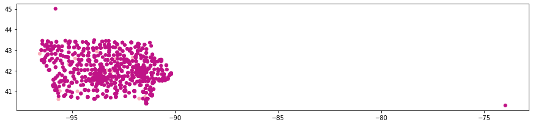

```python
# Creating the Geographical Location of Liquor Stores
df_geo = gpd.GeoDataFrame(liquorSales, geometry = 'Store_Location')

df_geo['Store_Location'].plot(figsize = (15, 50), markersize = 25, cmap = 'RdPu')
```

```python
# Creating Year and Month from Date column
liquorSales['Year'] = pd.DatetimeIndex(liquorSales['Date']).year
liquorSales['Month'] = pd.DatetimeIndex(liquorSales['Date']).month
```

```python
# Calculating the sum of sales for each year
df = pd.DataFrame()
df['sales'] = liquorSales.groupby(['Year']).Sale.sum()
df.info()
```

```
<class 'pandas.core.frame.DataFrame'>
Int64Index: 3 entries, 2019 to 2021
Data columns (total 1 columns):
 #   Column  Non-Null Count  Dtype
---  ------  --------------  -----
 0   sales   3 non-null      float64
dtypes: float64(1)
memory usage: 48.0 bytes
```

### What is the trend of liquor sales across various years?

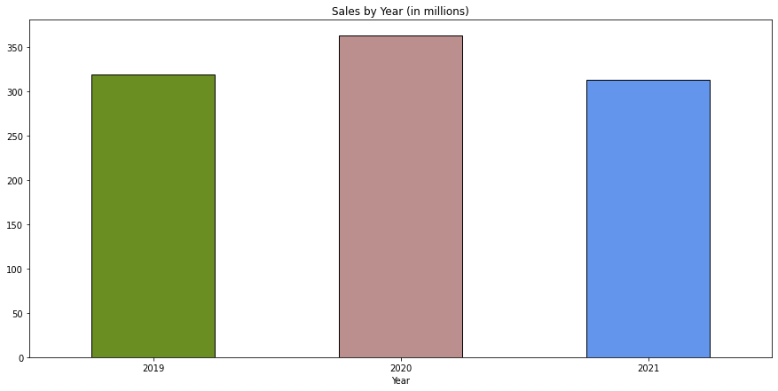

```python
# Plotting Sales by Year (in millions) in bar chart
dftmp = liquorSales.groupby(["Year"]).Sale.sum()/1000000
dftmp.plot(kind = "bar", title = "Sales by Year (in millions)", figsize = (15,7), rot = 0, y = 'Sale', color = ['olivedrab','rosybrown', 'cornflowerblue'], edgecolor = 'black')
```

#### We found that the liquor sales is higher during Covid pandemic compared to Pre-Covid.

```python
# Importing month from calendar package
liquorSales["Months"] = liquorSales["Month"].apply(lambda x: calendar.month_abbr[x])
```

```python
liquorSales.Months.unique()
```

```
array(['Jan', 'Feb', 'Mar', 'Apr', 'May', 'Jun', 'Jul', 'Aug', 'Sep',
       'Oct', 'Nov', 'Dec'], dtype=object)
```

```python
dftmp = pd.pivot_table(liquorSales, index = ["Month", "Months"], columns = ["Year"], values = "Sale", aggfunc = np.sum)
dftmp = dftmp/1000000
dftmp
```

| Month | Year Months | 2019 | 2020 | 2021 |
| --- | --- | --- | --- | --- |
| 1 | Jan | 21.419416 | 22.735807 | 26.155304 |
| 2 | Feb | 22.574256 | 23.695817 | 26.927115 |
| 3 | Mar | 22.772537 | 28.598157 | 33.396423 |
| 4 | Apr | 25.469049 | 29.062027 | 31.647159 |
| 5 | May | 29.819082 | 29.240305 | 30.751235 |
| 6 | Jun | 26.443223 | 33.189310 | 35.544004 |
| 7 | Jul | 28.257479 | 31.432704 | 32.075347 |
| 8 | Aug | 26.083522 | 31.120990 | 33.231459 |
| 9 | Sep | 25.797431 | 33.467923 | 32.637967 |
| 10 | Oct | 31.345779 | 33.937109 | 30.271123 |
| 11 | Nov | 27.648884 | 28.968068 | NaN |
| 12 | Dec | 31.694569 | 37.006023 | NaN |

### What is the trend of liquor sales across months for different categories and years?

```python
# Plotting Liquor Sales Trend Across Months for different categories and years in an interactive line chart
w_Category = widgets.Dropdown(
description = 'Category:',
options = ['All'] + sorted(list(set(liquorSales['Category of Liquor']))),
value = 'All',
style = {"description_width": '80px'},
layout = Layout(width = "17%")
)

def view(Category):

    if Category == 'All':
        dftmp = liquorSales

    else:
        dftmp = liquorSales[liquorSales['Category of Liquor'] == Category]


    dftmp2 = pd.pivot_table(dftmp, index = ["Month", "Months"], columns = ["Year"], values = "Sale", aggfunc = np.sum)
    dftmp2 = dftmp2/1000000

    months = liquorSales.Months.unique()

    fig, ax = plt.subplots(figsize = (15, 7))

    # Define x and y axes
    ax.plot(months,dftmp2[2019],color = "#20B2AA")
    ax.plot(months,dftmp2[2020],color = "#DB7093")
    ax.plot(months,dftmp2[2021],color = "#4B0082")
    ax.legend(["2019", "2020", "2021"])

    plt.title("Liquor Sales Trend Across Months for {} Category".format(Category))
    plt.xlabel("Months")
    plt.ylabel("Sales (in millions)")

i = interactive(view,Category = w_Category)
display(i)
```

### What is the most preferred liquor type for different years?

```python
# Plotting Sales by Category (in millions) for various years in an interactive bar chart
w_year = widgets.RadioButtons(description = 'Year:',
                              options = ['All'] + sorted(list(set(liquorSales['Year']))),
                              value = 'All',
                              style = {"description_width": '80px'},
                              layout = Layout(width = "17%"))

def view(year):

    if year == 'All':
        dftmp = liquorSales

    else:
        dftmp = liquorSales[liquorSales['Year'] == year]

    dftmp2 = dftmp.groupby(["Category of Liquor"]).Sale.sum()/1000000

    dftmp2.plot(kind = "bar", title = "Sales by Category (in millions)", figsize = (15,7), rot = 0, y = 'Sale', color = ['#DB7093','#C71585','#D8BFD8','#BC8F8F', '#FFB6C1', '#CD5C5C'], edgecolor = 'black')

i = interactive(view, year = w_year)
display(i)
```

### Identify the top 10 and bottom 10 stores or vendors based on sales.

```python
w_report = widgets.RadioButtons(
description = 'Store or Vendor',
options = ['Store', 'Vendor'],
value = 'Store',
style = {'description_width': '130px'},
layout = Layout(width = "65%")
)

w_report1 = widgets.RadioButtons(
description = 'Top 10 and Bottom 10 Vendors or Stores in Sales',
options = ['Top 10', 'Bottom 10'],
value = 'Top 10',
style = {'description_width': '310px'},
layout = Layout(width = "65%")
)

def view(store_or_vendor, top_Or_Bottom):

    if( store_or_vendor == 'Store'):
        df = liquorSales.groupby(["Store_Name"]).Sale.sum()

    else:
        df = liquorSales.groupby(["Vendor_Name"]).Sale.sum()


    if( top_Or_Bottom == 'Top 10'):
        df = df.nlargest(n=10)
    else:
        df = df.nsmallest(n=10)


    display(df)

i=interactive(view,store_or_vendor = w_report, top_Or_Bottom = w_report1)
display(i)
```

## Regression

```python
# Create a correlation heatmap
def correlation_heat_map(df):
    corrs = df.corr()

    # Set the default matplotlib figure size:
    fig, ax = plt.subplots(figsize = (20,7))

    # Generate a mask for the upper triangle
    mask = np.zeros_like(corrs, dtype = np.bool)
    mask[np.triu_indices_from(mask)] = True

    # Plot the heatmap with Seaborn.
    # Assign the matplotlib axis the function returns.
    #This allow us to resize the labels.
    ax = sns.heatmap(corrs, mask = mask, annot = True, vmin = -1, vmax = 1)

    ax.set_xticklabels(ax.xaxis.get_ticklabels(), fontsize = 12, rotation = 70)
    ax.set_yticklabels(ax.yaxis.get_ticklabels(), fontsize = 12, rotation = 0)

    plt.show()
```

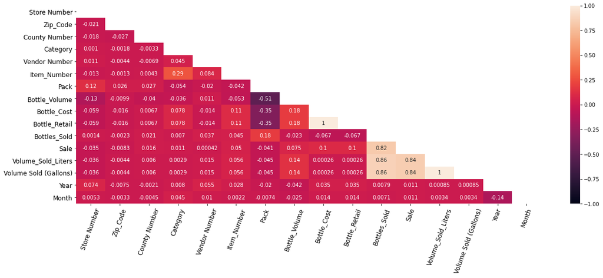

```python
correlation_heat_map(liquorSales)
```

```python
# Preparing training and testing data

# Creating new column of net profit per bottle for each bottle
liquorSales['Bottle_Profit'] = liquorSales['Bottle_Retail'] - liquorSales['Bottle_Cost']
liquorSales.append(df)


# define X and y
X = liquorSales[['Pack', 'Bottle_Volume', 'Bottle_Profit', 'Bottles_Sold', 'Volume_Sold_Liters']]
y = liquorSales['Sale']

# split into training and testing sets
X_train, X_test, y_train, y_test = train_test_split(X, y, test_size = 0.3) # test data will be 30% of entire df
print(X_train.shape, y_train.shape)
print(X_test.shape, y_test.shape)
```

```
(4514433, 5) (4514433,)
(1934757, 5) (1934757,)
```

```python
# Fit model
lm = linear_model.LinearRegression()

model = lm.fit(X_train, y_train)
predictions = lm.predict(X_test)
```

```
Test Score: 0.7586207061980137
Train Score: 0.7725309445168949
```

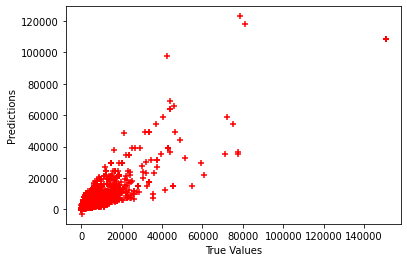

```python
# The line / model
plt.scatter(y_test, predictions, marker = '+', color = 'r')
plt.xlabel("True Values")
plt.ylabel("Predictions")
print("Test Score: {}".format(model.score(X_test, y_test)))
print("Train Score: {}".format(model.score(X_train, y_train)))
```

### What is the most significant variable that influences the liquor sales of a store in Iowa?

```python
# Checking the P-value of Independent Variables
model = sms.OLS(y, X).fit()
model.summary()
```

OLS Regression Results

| Dep. Variable: | Sale | R-squared (uncentered): | 0.784 |
| --- | --- | --- | --- |
| Model: | OLS | Adj. R-squared (uncentered): | 0.784 |
| Method: | Least Squares | F-statistic: | 4.694e+06 |
| Date: | Wed, 08 Dec 2021 | Prob (F-statistic): | 0.00 |
| Time: | 22:20:38 | Log-Likelihood: | -4.5209e+07 |
| No. Observations: | 6449190 | AIC: | 9.042e+07 |
| Df Residuals: | 6449185 | BIC: | 9.042e+07 |
| Df Model: | 5 |  |  |
| Covariance Type: | nonrobust |  |  |

|  | coef | std err | t | P>\|t\| | [0.025 | 0.975] |
| --- | --- | --- | --- | --- | --- | --- |
| Pack | -4.2479 | 0.010 | -420.582 | 0.000 | -4.268 | -4.228 |
| Bottle_Volume | -0.0197 | 0.000 | -121.012 | 0.000 | -0.020 | -0.019 |
| Bottle_Profit | 13.8729 | 0.021 | 675.218 | 0.000 | 13.833 | 13.913 |
| Bottles_Sold | 7.4392 | 0.007 | 1119.266 | 0.000 | 7.426 | 7.452 |
| Volume_Sold_Liters | 6.0873 | 0.006 | 1096.862 | 0.000 | 6.076 | 6.098 |

| Omnibus: | 17124449.542 | Durbin-Watson: | 1.996 |
| --- | --- | --- | --- |
| Prob(Omnibus): | 0.000 | Jarque-Bera (JB): | 16841688162055.086 |
| Skew: | 30.264 | Prob(JB): | 0.00 |
| Kurtosis: | 7919.499 | Cond. No. | 195. |

Warnings:  
[1] Standard Errors assume that the covariance matrix of the errors is correctly specified.